# **Bank Churn Prediction Project**

## **Background and Context**

Businesses like banks that provide service have to worry about the problem of 'Churn' i.e. customers leaving and joining another service provider. It is important to understand which aspects of the service influence a customer's decision in this regard. Management can concentrate efforts on the improvement of service, keeping in mind these priorities.

### **Objective**

Given a Bank customer, build a neural network-based classifier that can determine whether they will leave or not in the next 6 months.

### **Data Description**

The case study is from an open-source dataset from Kaggle. The dataset contains 10,000 sample points with 14 distinct features such as CustomerId, CreditScore, Geography, Gender, Age, Tenure, Balance, etc.

### **Data Dictionary**

  ```
                0=No ( Customer did not leave the bank )

                1=Yes ( Customer left the bank )
  ```

## **Code goes here...**

First I need the libraries to load, visualie, analyze, and scale data. Then I need the libraries to create the ANN.

```python
# Libraries to help with reading and manipulating data
import numpy as np
import pandas as pd

# Libraries to help with data visualization
import matplotlib.pyplot as plt
import seaborn as sns

# To tune model, get different metric scores and split data, and also to search for the best model using rnadomized search
from sklearn.model_selection import train_test_split
from sklearn import metrics
from sklearn.metrics import f1_score, accuracy_score, recall_score, precision_score, confusion_matrix, roc_auc_score, roc_curve, plot_confusion_matrix

# To impute missing values
from sklearn.impute import KNNImputer, SimpleImputer

# to scale the data using z-score - needed to ensure that all data dimensions have equal influence
from sklearn.preprocessing import StandardScaler

# To suppress the warnings
import warnings

warnings.filterwarnings("ignore")

# To be used for creating pipelines and personalizing them
from sklearn.pipeline import Pipeline
from sklearn.compose import ColumnTransformer

# To define maximum number of columns to be displayed in a dataframe
pd.set_option("display.max_columns", None)

# To supress scientific notations for a dataframe
pd.set_option("display.float_format", lambda x: "%.3f" % x)
```

```python
# Tensorflow and Keras
import tensorflow as tf
from tensorflow import keras
from tensorflow.keras import backend as K
from tensorflow.keras.models import Sequential
from tensorflow.keras.layers import Dense, Dropout
from tensorflow.keras.optimizers import Adam
from tensorflow.keras.optimizers import SGD
```

### **Load Data, make a copy, and do some initial inspection of data**

```python
# Let's load the data
bankData = pd.read_csv("bank.csv")
```

```python
# Make a copy of the data for safekeeping
df = bankData.copy()
```

## **Initial Data Inspection**

```python
# And take a quick look at how many rows and columns are there
df.shape
```

```
(10000, 14)
```

There are 10,000 rows and 14 columns in the data.

```python
# Let's inspect first few rows
df.head(10)
```

|  | RowNumber | CustomerId | Surname | CreditScore | Geography | Gender | Age | Tenure | Balance | NumOfProducts | HasCrCard | IsActiveMember | EstimatedSalary | Exited |
| --- | --- | --- | --- | --- | --- | --- | --- | --- | --- | --- | --- | --- | --- | --- |
| 0 | 1 | 15634602 | Hargrave | 619 | France | Female | 42 | 2 | 0.000 | 1 | 1 | 1 | 101348.880 | 1 |
| 1 | 2 | 15647311 | Hill | 608 | Spain | Female | 41 | 1 | 83807.860 | 1 | 0 | 1 | 112542.580 | 0 |
| 2 | 3 | 15619304 | Onio | 502 | France | Female | 42 | 8 | 159660.800 | 3 | 1 | 0 | 113931.570 | 1 |
| 3 | 4 | 15701354 | Boni | 699 | France | Female | 39 | 1 | 0.000 | 2 | 0 | 0 | 93826.630 | 0 |
| 4 | 5 | 15737888 | Mitchell | 850 | Spain | Female | 43 | 2 | 125510.820 | 1 | 1 | 1 | 79084.100 | 0 |
| 5 | 6 | 15574012 | Chu | 645 | Spain | Male | 44 | 8 | 113755.780 | 2 | 1 | 0 | 149756.710 | 1 |
| 6 | 7 | 15592531 | Bartlett | 822 | France | Male | 50 | 7 | 0.000 | 2 | 1 | 1 | 10062.800 | 0 |
| 7 | 8 | 15656148 | Obinna | 376 | Germany | Female | 29 | 4 | 115046.740 | 4 | 1 | 0 | 119346.880 | 1 |
| 8 | 9 | 15792365 | He | 501 | France | Male | 44 | 4 | 142051.070 | 2 | 0 | 1 | 74940.500 | 0 |
| 9 | 10 | 15592389 | H? | 684 | France | Male | 27 | 2 | 134603.880 | 1 | 1 | 1 | 71725.730 | 0 |

```python
# And the last few rows
df.tail(10)
```

|  | RowNumber | CustomerId | Surname | CreditScore | Geography | Gender | Age | Tenure | Balance | NumOfProducts | HasCrCard | IsActiveMember | EstimatedSalary | Exited |
| --- | --- | --- | --- | --- | --- | --- | --- | --- | --- | --- | --- | --- | --- | --- |
| 9990 | 9991 | 15798964 | Nkemakonam | 714 | Germany | Male | 33 | 3 | 35016.600 | 1 | 1 | 0 | 53667.080 | 0 |
| 9991 | 9992 | 15769959 | Ajuluchukwu | 597 | France | Female | 53 | 4 | 88381.210 | 1 | 1 | 0 | 69384.710 | 1 |
| 9992 | 9993 | 15657105 | Chukwualuka | 726 | Spain | Male | 36 | 2 | 0.000 | 1 | 1 | 0 | 195192.400 | 0 |
| 9993 | 9994 | 15569266 | Rahman | 644 | France | Male | 28 | 7 | 155060.410 | 1 | 1 | 0 | 29179.520 | 0 |
| 9994 | 9995 | 15719294 | Wood | 800 | France | Female | 29 | 2 | 0.000 | 2 | 0 | 0 | 167773.550 | 0 |
| 9995 | 9996 | 15606229 | Obijiaku | 771 | France | Male | 39 | 5 | 0.000 | 2 | 1 | 0 | 96270.640 | 0 |
| 9996 | 9997 | 15569892 | Johnstone | 516 | France | Male | 35 | 10 | 57369.610 | 1 | 1 | 1 | 101699.770 | 0 |
| 9997 | 9998 | 15584532 | Liu | 709 | France | Female | 36 | 7 | 0.000 | 1 | 0 | 1 | 42085.580 | 1 |
| 9998 | 9999 | 15682355 | Sabbatini | 772 | Germany | Male | 42 | 3 | 75075.310 | 2 | 1 | 0 | 92888.520 | 1 |
| 9999 | 10000 | 15628319 | Walker | 792 | France | Female | 28 | 4 | 130142.790 | 1 | 1 | 0 | 38190.780 | 0 |

#### Observations

- Looks like the `RowNumber` column is just a unique identifier and can be removed.
- `CustomerId` also appears to be unique and can be removed.
- The `Surname` wouldn't have any bearing on the data analysis eaither and can removed.
- The `Geography` appears to indicate a country. We will need to one-hot-encode this.
- The `Gender` will need one-hot-encoding as well.
- There are some 0.000 data in Balance. This appears to be a data problem since the corresponding EstimatedSalary looks high, but we can inspect further.

```python
# Let's inspect the data types and null counts
df.info()
```

```
<class 'pandas.core.frame.DataFrame'>
RangeIndex: 10000 entries, 0 to 9999
Data columns (total 14 columns):
 #   Column           Non-Null Count  Dtype
---  ------           --------------  -----
 0   RowNumber        10000 non-null  int64
 1   CustomerId       10000 non-null  int64
 2   Surname          10000 non-null  object
 3   CreditScore      10000 non-null  int64
 4   Geography        10000 non-null  object
 5   Gender           10000 non-null  object
 6   Age              10000 non-null  int64
 7   Tenure           10000 non-null  int64
 8   Balance          10000 non-null  float64
 9   NumOfProducts    10000 non-null  int64
 10  HasCrCard        10000 non-null  int64
 11  IsActiveMember   10000 non-null  int64
 12  EstimatedSalary  10000 non-null  float64
 13  Exited           10000 non-null  int64
dtypes: float64(2), int64(9), object(3)
memory usage: 1.1+ MB
```

There doesn't appear to be any null data, but we can further verify that. The `Geography` and `Gender` column have non-numeric data, as our initial inspection showed. Rest of the columns are all numeric.

```python
# Let's get a further confirmation the lack of nulls
df.isnull().sum()
```

```
RowNumber          0
CustomerId         0
Surname            0
CreditScore        0
Geography          0
Gender             0
Age                0
Tenure             0
Balance            0
NumOfProducts      0
HasCrCard          0
IsActiveMember     0
EstimatedSalary    0
Exited             0
dtype: int64
```

```python
# Let's get a picture of the numeric columns
df.describe().T
```

|  | count | mean | std | min | 25% | 50% | 75% | max |
| --- | --- | --- | --- | --- | --- | --- | --- | --- |
| RowNumber | 10000.000 | 5000.500 | 2886.896 | 1.000 | 2500.750 | 5000.500 | 7500.250 | 10000.000 |
| CustomerId | 10000.000 | 15690940.569 | 71936.186 | 15565701.000 | 15628528.250 | 15690738.000 | 15753233.750 | 15815690.000 |
| CreditScore | 10000.000 | 650.529 | 96.653 | 350.000 | 584.000 | 652.000 | 718.000 | 850.000 |
| Age | 10000.000 | 38.922 | 10.488 | 18.000 | 32.000 | 37.000 | 44.000 | 92.000 |
| Tenure | 10000.000 | 5.013 | 2.892 | 0.000 | 3.000 | 5.000 | 7.000 | 10.000 |
| Balance | 10000.000 | 76485.889 | 62397.405 | 0.000 | 0.000 | 97198.540 | 127644.240 | 250898.090 |
| NumOfProducts | 10000.000 | 1.530 | 0.582 | 1.000 | 1.000 | 1.000 | 2.000 | 4.000 |
| HasCrCard | 10000.000 | 0.706 | 0.456 | 0.000 | 0.000 | 1.000 | 1.000 | 1.000 |
| IsActiveMember | 10000.000 | 0.515 | 0.500 | 0.000 | 0.000 | 1.000 | 1.000 | 1.000 |
| EstimatedSalary | 10000.000 | 100090.240 | 57510.493 | 11.580 | 51002.110 | 100193.915 | 149388.247 | 199992.480 |
| Exited | 10000.000 | 0.204 | 0.403 | 0.000 | 0.000 | 0.000 | 0.000 | 1.000 |

## **Data Pre-Processing**

```python
# Drop the columns that we will not use for the analysis
df.drop("RowNumber", axis=1, inplace=True)
df.drop("CustomerId", axis=1, inplace=True)
df.drop("Surname", axis=1, inplace=True)
```

```python
df.info()
```

```
<class 'pandas.core.frame.DataFrame'>
RangeIndex: 10000 entries, 0 to 9999
Data columns (total 11 columns):
 #   Column           Non-Null Count  Dtype
---  ------           --------------  -----
 0   CreditScore      10000 non-null  int64
 1   Geography        10000 non-null  object
 2   Gender           10000 non-null  object
 3   Age              10000 non-null  int64
 4   Tenure           10000 non-null  int64
 5   Balance          10000 non-null  float64
 6   NumOfProducts    10000 non-null  int64
 7   HasCrCard        10000 non-null  int64
 8   IsActiveMember   10000 non-null  int64
 9   EstimatedSalary  10000 non-null  float64
 10  Exited           10000 non-null  int64
dtypes: float64(2), int64(7), object(2)
memory usage: 859.5+ KB
```

```python
# Let's convert the 2 string columns into categorical columns
str_cols = ['Gender', 'Geography']
for col in str_cols:
    df[col] = df[col].astype('category')
```

```python
df.info()
```

```
<class 'pandas.core.frame.DataFrame'>
RangeIndex: 10000 entries, 0 to 9999
Data columns (total 11 columns):
 #   Column           Non-Null Count  Dtype
---  ------           --------------  -----
 0   CreditScore      10000 non-null  int64
 1   Geography        10000 non-null  category
 2   Gender           10000 non-null  category
 3   Age              10000 non-null  int64
 4   Tenure           10000 non-null  int64
 5   Balance          10000 non-null  float64
 6   NumOfProducts    10000 non-null  int64
 7   HasCrCard        10000 non-null  int64
 8   IsActiveMember   10000 non-null  int64
 9   EstimatedSalary  10000 non-null  float64
 10  Exited           10000 non-null  int64
dtypes: category(2), float64(2), int64(7)
memory usage: 723.0 KB
```

## **Exploratory Data Analysis**

### Note

I am borrowing/copying some utility functions that were used in the MLS sessions instead of trying to create them on my own.

I am borrowing utility functions for univariate analysis as well as for bivariate analysis.

```python
# function to plot a boxplot and a histogram along the same scale.


def histogram_boxplot(data, feature, figsize=(12, 7), kde=False, bins=None):
    """
    Boxplot and histogram combined

    data: dataframe
    feature: dataframe column
    figsize: size of figure (default (12,7))
    kde: whether to the show density curve (default False)
    bins: number of bins for histogram (default None)
    """
    f2, (ax_box2, ax_hist2) = plt.subplots(
        nrows=2,  # Number of rows of the subplot grid= 2
        sharex=True,  # x-axis will be shared among all subplots
        gridspec_kw={"height_ratios": (0.25, 0.75)},
        figsize=figsize,
    )  # creating the 2 subplots
    sns.boxplot(
        data=data, x=feature, ax=ax_box2, showmeans=True, color="violet"
    )  # boxplot will be created and a star will indicate the mean value of the column
    sns.histplot(
        data=data, x=feature, kde=kde, ax=ax_hist2, bins=bins, palette="winter"
    ) if bins else sns.histplot(
        data=data, x=feature, kde=kde, ax=ax_hist2
    )  # For histogram
    ax_hist2.axvline(
        data[feature].mean(), color="green", linestyle="--"
    )  # Add mean to the histogram
    ax_hist2.axvline(
        data[feature].median(), color="black", linestyle="-"
    )  # Add median to the histogram
```

```python
# function to create labeled barplots


def labeled_barplot(data, feature, perc=False, n=None):
    """
    Barplot with percentage at the top

    data: dataframe
    feature: dataframe column
    perc: whether to display percentages instead of count (default is False)
    n: displays the top n category levels (default is None, i.e., display all levels)
    """

    total = len(data[feature])  # length of the column
    count = data[feature].nunique()
    if n is None:
        plt.figure(figsize=(count + 1, 5))
    else:
        plt.figure(figsize=(n + 1, 5))

    plt.xticks(rotation=90, fontsize=15)
    ax = sns.countplot(
        data=data,
        x=feature,
        palette="Paired",
        order=data[feature].value_counts().index[:n].sort_values(),
    )

    for p in ax.patches:
        if perc == True:
            label = "{:.1f}%".format(
                100 * p.get_height() / total
            )  # percentage of each class of the category
        else:
            label = p.get_height()  # count of each level of the category

        x = p.get_x() + p.get_width() / 2  # width of the plot
        y = p.get_height()  # height of the plot

        ax.annotate(
            label,
            (x, y),
            ha="center",
            va="center",
            size=12,
            xytext=(0, 5),
            textcoords="offset points",
        )  # annotate the percentage

    plt.show()  # show the plot
```

### **Univariate Analysis**

First I will do some histogram and boxplots for the numerical variables that are continuous in nature.

Then I will do barplots for some of the numerical data that are more categorical in nature -- for example NumOfProducts and HasCrCard,

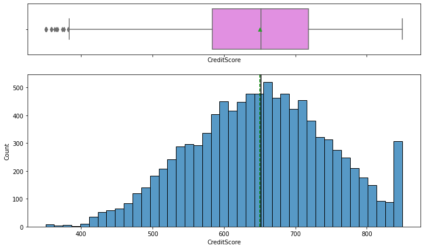

```python
histogram_boxplot(df, "CreditScore")
```

The credit card score has a normal distribution with some outliers towards the bottom.

There are a set of high credit card numbers which have the highest score, which means that the bank has some very high value customers.

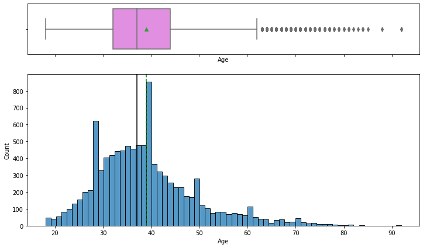

```python
histogram_boxplot(df, "Age")
```

Tne graph is right-skewed and there are numerous outliers for 'Age'. In order to improve the performance of the model, I will need to cap the outliers during Feature engineering.

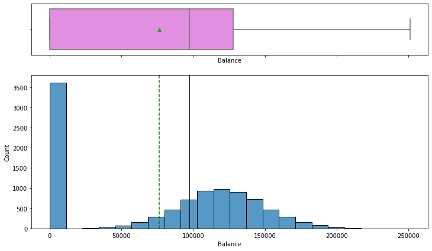

```python
histogram_boxplot(df, "Balance")
```

The graph has a normal distribution except for a large number of records for which the balance is 0. This appears to be a typo as there is no reason for the balance to be zero for these customers.

I will need to impute these values during feature engineering.

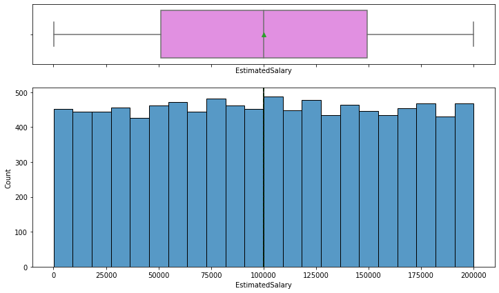

```python
histogram_boxplot(df, "EstimatedSalary")
```

The estimated salary appears to be evenly distributed, which is a bit odd because salary distributions tend to be normal graphs. There are no outliers here to worry about.

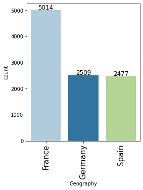

```python
labeled_barplot(df, "Geography")
```

All data is tied to the three countries - France, Germany, adn Spain. I will need to hot-one-encode the data.

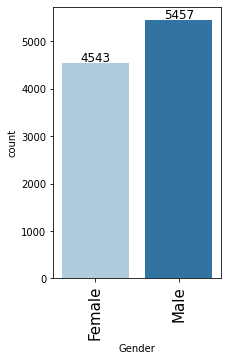

```python
labeled_barplot(df, "Gender")
```

The gender distribution does not have any noisy data and the genders are limited to male and female. I will need to hot-one-encode this data as well since it is categorical.

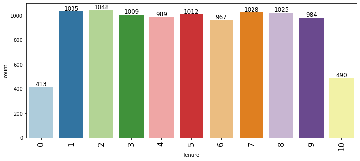

```python
labeled_barplot(df, "Tenure")
```

The tenure is an even distribution, which is a goo sign for the bank. This means that they have been acuiring new customers every year.

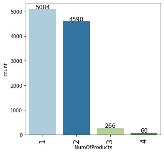

```python
labeled_barplot(df, "NumOfProducts")
```

The Number of products graph is nothing unusual. Customers usually have one product with the bank, and the population having more products tapers off. This indicates opportunities for the bank to improve sales.

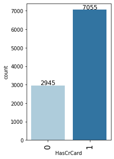

```python
labeled_barplot(df, "HasCrCard")
```

70% of the customers have a credit card, which is a good sign for the bank. This is essentially boolean data.

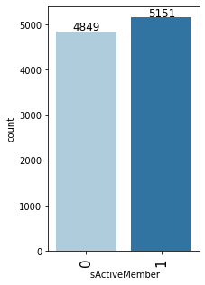

```python
labeled_barplot(df, "IsActiveMember")
```

It is odd to see as many non-active members of the bank. This provides an opportunity for the bank to engage with the customers and improve retention.

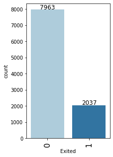

```python
labeled_barplot(df, "Exited")
```

This is the distribution of the target variable/class. There is imbalance between the two classes but it is not extreme. 80% of customers stay with the bank, while 20% of customers switch to a new bank.